## ARI Data Analysis in 2013

A Dhaka tribune report was published last April 3,2015. The study has been commissioned by Passenger Welfare Commission based on data collected from several news papers in Bangladesh. Here are some of the facts that came out of the report.

From January-December 2014  
5,928

[figure not shown]

Road accidents  
8,589

[figure not shown]

killed!  
17,523

[figure not shown]

were hurt!  
1,623

[figure not shown]

suffered life-long injuries

What does this mean?

Each hour, Each day someone in 2014 got killed in road accidents

Each hour and a half, each day, an accident happened in 2014

Each hour at least two person got injured in 2014

Everyday more than 4 persons suffered long term injuries

In an [Guardian article](http://goo.gl/sgNdnc)we get the following facts

Every Three hours each day on the average two accidents In the same report we find that National Road Safety Council (NRSC) mentioning that published in January that over the last five years, road accidents claimed 2,529 lives on average every year, while last year’s death toll was below 2,000.The NRSC report is based on data collected from police headquarters.

In the following we see a graph of the different types of Accidents distribution in 2013

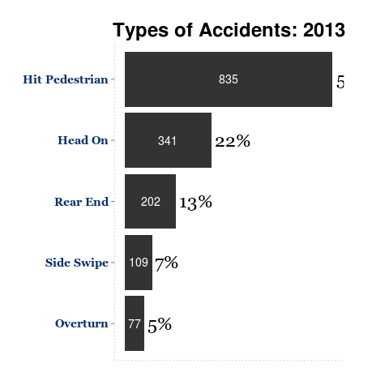

### Death on the Road: The New-age Epidemic By Afsana Tazreen and Daniel M. Sabet January 2014 Current Events Analysis Series

According to official police statistics, during the last ten years, there have been approximately 3,000 annual traffic related deaths in Bangladesh

According to the Accident Research Institute (ARI) at the Bangladesh University of Engineering and Technology, there are approximately 60 annual fatalities per 10,000 motor vehicles in Bangladesh, compared to 25 in India, 16 in Sri Lanka and 2 in the United States.

Dhaka has grown at an alarming rate. From 1995-2010, it added an average of over 400,000 residents every year, a rate of growth that exceeded most other major global cities (with the exception of New Delhi and Shanghai). Accompanying this population increase has been the rise in the number of vehicles on the roads, which increased by 133 percent over the period from 2004 to mid-2012, from 303,215 vehicles to 708,197 vehicles.i

Despite this reality, there are only 41 BRTA inspectors to check all 83 components of 1,500,000 vehicles each year.

This is [WHO Report (pdf version)](http://goo.gl/TmWfgw) which says the following things:

According to the World Health Organisation’s (WHO) Global Status Report on Road Safety 2013, road traffic injuries are the eighth leading cause of death globally, and the leading cause of death for young people aged 15–29 years. Approximately 1.24 million people die every year on the world’s roads, and another 20 to 50 million sustain non-fatal injuries as a result of traffic accidents. 186,300 children die globally each year from road traffic crashes – that’s more than 500 children every day and one every four minute

In Bangladesh, deaths from road traffic crashes are notably high with an estimated fatality rate of 13.6 deaths per 100,000 people in 2013. For many years this issue did not receive enough attention in Bangladesh. However, Bangladesh has now adopted a National Road Safety Strategy and a National Road Safety Council to act as a lead agency and the target is to reduce fatality by 10 percent every year. WHO contributed to the development of the National Action plan for Road Safety in Bangladesh 2011-2020. It is estimated that the country’s GDP loss due to road traffic crashes is 1.6 percent. However, Bangladesh is yet to formulate laws to address all five key risk factors and struggles to enforce those that exist.

According to the same report, 41 percent of the road traffic deaths in Bangladesh occur among pedestrians.